# The King’s College (New York, NY)

### Diversity among the students

|  | Undergrad (count) | Grad student (count) | Undergrads (percent) | Grad students (percent) |
| --- | --- | --- | --- | --- |
| Grand total men | 179 | 0 | 34.2% | NaN% |
| Grand total women | 344 | 0 | 65.8% | NaN% |
| American Indian or Alaska Native men | 5 | 0 | 1% | NaN% |
| American Indian or Alaska Native women | 3 | 0 | 0.6% | NaN% |
| Asian men | 5 | 0 | 1% | NaN% |
| Asian women | 16 | 0 | 3.1% | NaN% |
| Black or African American men | 7 | 0 | 1.3% | NaN% |
| Black or African American women | 24 | 0 | 4.6% | NaN% |
| Hispanic men | 17 | 0 | 3.3% | NaN% |
| Hispanic women | 38 | 0 | 7.3% | NaN% |
| Native Hawaiian or Other Pacific Islander men | 0 | 0 | 0% | NaN% |
| Native Hawaiian or Other Pacific Islander women | 0 | 0 | 0% | NaN% |
| White men | 119 | 0 | 22.8% | NaN% |
| White women | 238 | 0 | 45.5% | NaN% |
| Two or more races men | 0 | 0 | 0% | NaN% |
| Two or more races women | 0 | 0 | 0% | NaN% |
| Race/ethnicity unknown men | 13 | 0 | 2.5% | NaN% |
| Race/ethnicity unknown women | 20 | 0 | 3.8% | NaN% |
| Nonresident alien men | 13 | 0 | 2.5% | NaN% |
| Nonresident alien women | 5 | 0 | 1% | NaN% |

### US student origins

First time degree seeking undergrads

**There are no available data on states of origin**

### Library resources

|  | Number | Number per undergrad |
| --- | --- | --- |
| Number of physical books | 11,700 | 22 |
| Number of physical media | 650 | 2 |
| Number of physical serials | 39 | 1 |
| Number of digital/electronic books | 175,000 | 322 |
| Number of digital/electronic databases | 24 | 24 |
| Number of digital/electronic media | 1 | 1 |
| Number of electronic serials | 10 | 1 |
| Total library collections (physical and electronic) | 187,424 | 345 |
| Total physical library circulations (books and media) | 1,042 | 2 |
| Total digital/electronic circulations (books and media) | 54,446 | 101 |
| Total library circulations (physical and digital/electronic) | 55,488 | 102 |
| Total interlibrary loans and documents provided to other libraries | 0 | 0 |
| Total interlibrary loans and documents received | 5 | 1 |

## Figures

### Student to faculty ratio compared to similar institutions:

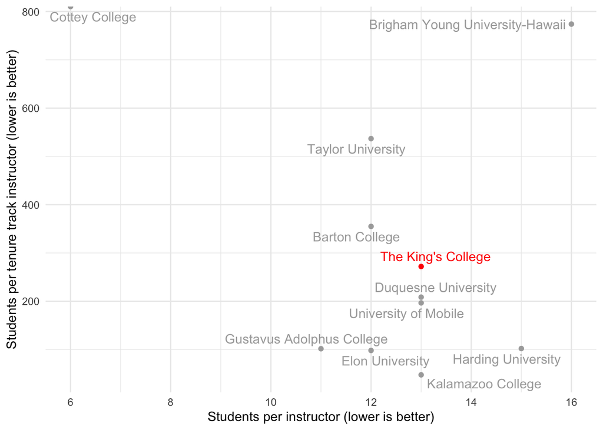